# Coursework Report

*N* removed NAs: 6

*N* removed <18: 24

**Correct typo age:** 18

*N* total clean: 138

| Group | *N* | *M*<sub>age</sub> | % green |
| --- | --- | --- | --- |
| Control | 70 | 21.0 | 36.2 |
| Experim | 68 | 20.7 | 50.0 |

| Gender | *N* | *M*<sub>age</sub> | % green |
| --- | --- | --- | --- |
| Female | 68 | 20.8 | 44.1 |
| Male | 45 | 21.0 | 43.7 |
| Other | 25 | 20.8 | 38.7 |

**Main analysis results**

**car:**  
χ<sup>2</sup>(1) = 0, *p* = .978

**cleaner:**  
χ<sup>2</sup>(1) = 5.67, *p* = .017

**dishwasher:**  
χ<sup>2</sup>(1) = 5.67, *p* = .017

[interactive chart not shown]

[figure not shown]

[interactive chart not shown]

# Coursework Report

Analysing Data, Spring 2020

# Methods

## Participants

The study consisted of 168 participants (*M*<sub>age</sub> = 20.85, *SD*<sub>age</sub> = 1.94, **Range** = 18 - 25). A total 30 participants were removed from the original sample. Due to ethical concerns surrounding the age of consent, 24 participants were removed for being under 18 years old, or for reporting an ambiguous age. Additionally, 6 participants were removed for missing critical data. In summary, a total 138 participants (68 Females, 45 Males, and 25 Others) remained for data analysis. Table 1 and Table 2 outlines the demography of the samples used for each condition.

**Table 1. Control Condition Demography**

| Gender | N | % | *M*<sub>Age</sub> | *SD*<sub>Age</sub> |
| --- | --- | --- | --- | --- |
| female | 39 | 55.7 | 21.0 | 2.02 |
| male | 24 | 34.3 | 21.1 | 2.06 |
| other | 7 | 10.0 | 20.9 | 1.85 |

**Table 2. Status Condition Demography**

| Gender | N | % | *M*<sub>Age</sub> | *SD*<sub>Age</sub> |
| --- | --- | --- | --- | --- |
| female | 29 | 42.6 | 20.6 | 1.84 |
| male | 21 | 30.9 | 20.8 | 1.76 |
| other | 18 | 26.5 | 20.7 | 2.01 |

## Design

The goal of this study is to assess how stimulating status-motives affects consumer choices between a selection of comparatively nongreen “luxury” products versus environmentally-friendly “green” products. Moreover, this hypothesis reflects the research question Griskevicius et al.’s (2010) propose in their original experiment 1 and this research acts to find whether their findings are replicable. Therefore, the variables and conditions within this experiment are operationalised within the same methodological framework as the original study.

An independent measures design has been replicated, wherein participants are assigned a condition factor (Levels = “Status”, “Control”). The independent variable is the reading material provided for each condition. In the status condition, a reading material intending to prime the feelings of status-desire is used. The control group otherwise received a neutral reading material with no intended effects. Both materials are extracted from the original study.

The dependent variable is the factor of product category (Levels = “Green”, “Luxury”) depending upon the product choice of the participant. The three separate products to assess choice are: a car, a dishwasher and a cleaner. Frequency of product category choices are discretely assessed for each product.

As Griskevicius et al.’s (2010) original findings suggest, our current hypothesis follows that participants in the status condition will have a relatively stronger association with green product preference compared to the control group. In other words, the control group will have a greater association with a product choice of the luxury level. A chi-squared test will be used to determine the relationship between the experimental condition by the green versus luxury category of each unique product choice (all *p*s < .05).

# Results

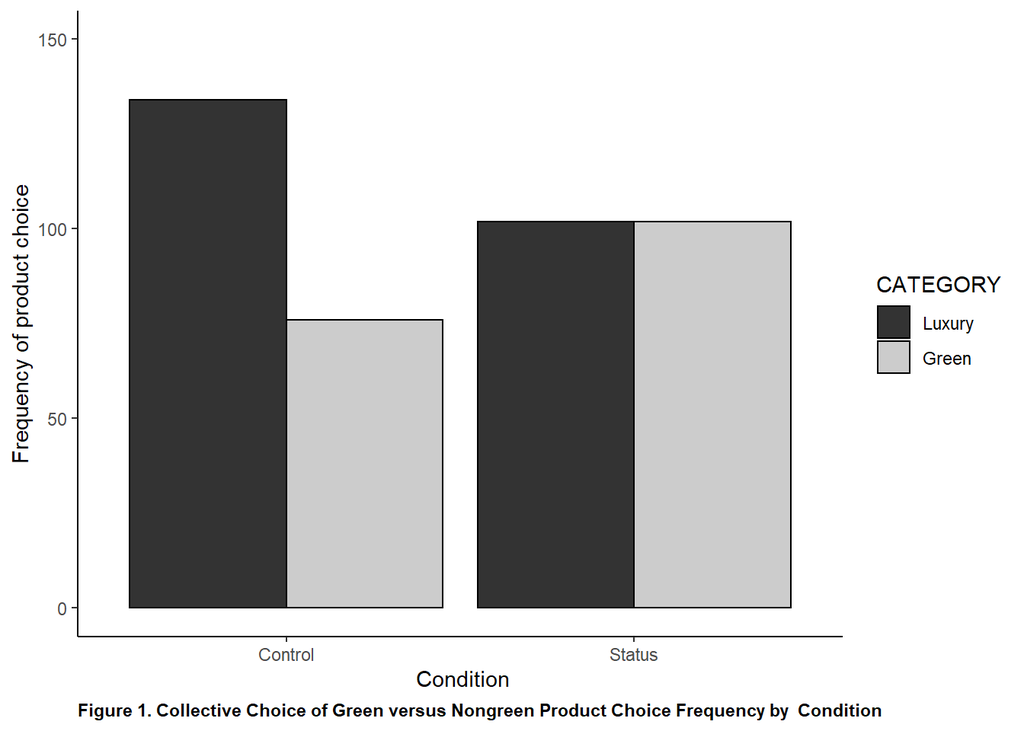

Overall, Figure 1 outlines the total frequency of all luxury versus green product choices across all products, by the control or status conditions accordingly. In the control condition, a total 36% of the green products was chose, whilst the participants in the status condition show a relatively greater 50% preference for green products.

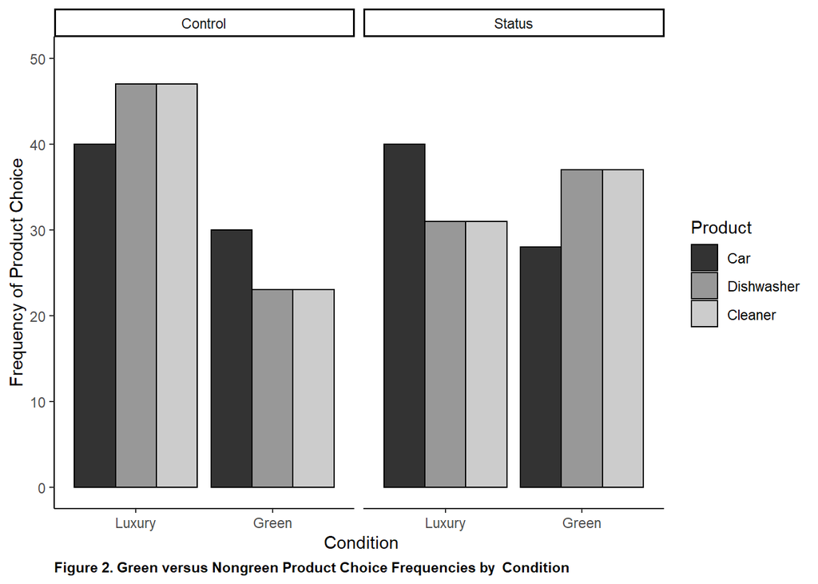

To analyse specific product preferences, Figure 2 shows the frequency of individual luxury versus green product choices by the control or status conditions accordingly. Participants chose the green car 43% in the control condition and 41% in the status condition, creating a -2% change. Contrary to the overall trend, the frequency of the luxury versus green product choice for the car was not affected by the experimental condition (*p* > 0.05), *χ*<sup>2</sup>(1) = 0, *p* = 0.978. Alternatively, 33% of control group participants selected the green dishwasher compared to 54% within status groups participants, forming a 22% increase. Matching the general trend, likelihood of preferring the green dishwasher is significantly increased by the status condition (*p* < 0.05), *χ*<sup>2</sup>(1) = 5.67, *p* = 0.017. Similarly, 33% of control condition participants prefer the green cleaner compared to 54% in the status condition, creating a 22% increase. Since the frequencies of the cleaner and dishwasher were equally distributed, the likelihood of choosing the green cleaner is identicle to the dishwasher, (*p* < 0.05), *χ*<sup>2</sup>(1) = 5.67, *p* = 0.017. In summary, both the dishwasher and cleaner products cohere with the operational hypothesis stating that the status condition increases likeliness to prefer green products (*p* < 0.05), except from the car product which was not affected (*p* > 0.05).

# Discussion

The findings of this experiment, offer an insight into how status motives can elicit greener purchasing behaviours, even when it may appear less cost-efficient or functional. In fact, simple attempts at memorising a status-desire inducing story show to alter an individual’s inclination for purchasing greener dishwashers and cleaning products. In support, status-desire stimulation in other research has shown increases of purchasing alternative green products, such as organic foods and hybrid cars (Puska et al., 2018; Sexton & Sexton, 2014). This research consolidates upon findings suggesting that status plays a role within environmental purchases at an international scale (Liobikienė et al., 2016). Thus, status should be further examined as a mechanism to encourage further greener purchases globally.

Findings within this field also support status as a mechanism for driving behaviour more broadly than an environmental context. If the underlying cause for less effective green goods is status at the cost of less luxury, it is appropriate that this status framework should not be exclusive to environmental contexts, but as a general desire principle. In fact, status is gaining significance in literature concerning power dynamics, fulfilling self-esteem and evoking anger in response to threats of status (Anderson et al., 2015). For example, threats to status are crucial in moderating expectations, such as the perceived stress of a stage performance, thus altering how individual’s behave in turn (Driskell & Mullen, 1990). Consequently, this suggests that future studies can analyse how reducing status affects the preference for greener products.

Although the general status effect has influence within this study, an inconsistency is found in that the car is not significantly affected by status, whilst green car preferences significantly did increase in Griskevicius et al.’s (2010) original findings. On one hand, alternative research conflicts with our findings, as Prius owners (a hybrid car) account their green car purchase to status and stating the reason as “makes a status about me” (Maynard, 2007). On the other hand, it is possible that the financial commitment to a car makes cost efficiency a greater concern, thus distracting and inhibiting status motives. For example, money independently has shown to amplify egocentric decisions, including ratings of oneself, therefore undermining the value of the lower value-for-money green car. Further studies can analyse varying weightings of cost versus status of a single product to gain greater insight in this dynamic.

Despite the general status-desire effect shown in this experiment, its between-groups methodology raises unanswered questions on how status motives affect a range of status-seeking dispositions. The general status-motivated purchasing effect observed across the cohorts may be more reflective of certain individuals who are more susceptible to status as an influence. For example, individuals who adopt a low-investment mating strategy have shown to be more susceptible to conspicuous purchases for status (Sundie et al., 2011). This prompts further research on the individuals who are unaffected by status motives and what qualities define them, which goes underappreciated in our findings.

Additionally, the methodology for status-desire is based on memorising a fictitious story which is unlike potential status-motivators commonly found in everyday life. The strength of this methodology is that it is versatile and low-cost for testing status-motives across a variety of other purchasing scenarios (Puska et al., 2018). However, other methodologies should be considered to consolidate status as the integral component for the green purchasing effect, instead of a unique characteristic of the story, such as the necessary self-reflection of confidence involved. Consequently, alternative life-like methodologies for raising desire for status, such as receiving compliments or face-to-face admiration, should be considered for raising ecological validity (Anderson et al., 2015; Holmes, 1988).

In conclusion, inducing status-desire does facilitate a preference for a range of greener purchases. Moreover, literature consolidates to evident that status-desire acts as a motivator across broader situations. Despite this, the limitations of our specific replication necessitates further research into external variables at play within our experiment, such as financial investment and individual differences. However, for a comprehensive understanding of status-desire effects a multitude of methodologies and comparisons with other drives should be investigated. Furthermore, the specific finding of status at the cost of lower luxury needs to be explored outside the context of environmental purchases. Moreover, the strength of status as a moderator should be greater contrasted against other desires, instead of just financial gain, to truly appreciate the significance of its effect.

# References

Anderson, C., Hildreth, J. A. D., & Howland, L. (2015). Is the desire for status a fundamental human motive? A review of the empirical literature. *Psychological Bulletin, 141(3),* 574–601. https://doi.org/10.1037/a0038781

Driskell, J. E., & Mullen, B. (1990). Status, Expectations, and Behavior: A Meta-Analytic Review and Test of the Theory. *Personality and Social Psychology Bulletin, 16(3),* 541–553. https://doi.org/10.1177/0146167290163012

Griskevicius, V., Tybur, J. M., & Van den Bergh, B. (2010). Going green to be seen: Status, reputation, and conspicuous conservation. *Journal of Personality and Social Psychology, 98(3),* 392–404. https://doi.org/10.1037/a0017346

Holmes, J. (1988). Paying compliments: A sex-preferential politeness strategy. *Journal of Pragmatics, 12(4),* 445–465. https://doi.org/10.1016/0378-2166(88)90005-7

Liobikienė, G., Mandravickaitė, J., & Bernatonienė, J. (2016). Theory of planned behavior approach to understand the green purchasing behavior in the EU: A cross-cultural study. *Ecological Economics, 125,* 38–46. https://doi.org/10.1016/j.ecolecon.2016.02.008

Maynard, M. (2007, July 4). Say ‘Hybrid’ and Many People Will Hear ‘Prius’. *The New York Times.* https://www.nytimes.com/2007/07/04/business/04hybrid.html

Puska, P., Kurki, S., Lähdesmäki, M., Siltaoja, M., & Luomala, H. (2018). Sweet taste of prosocial status signaling: When eating organic foods makes you happy and hopeful. *Appetite, 121,* 348–359. https://doi.org/10.1016/j.appet.2017.11.102

Sexton, S. E., & Sexton, A. L. (2014). Conspicuous conservation: The Prius halo and willingness to pay for environmental bona fides. *Journal of Environmental Economics and Management, 67(3),* 303–317. https://doi.org/10.1016/j.jeem.2013.11.004

Sundie, J. M., Kenrick, D. T., Griskevicius, V., Tybur, J. M., Vohs, K. D., & Beal, D. J. (2011). Peacocks, Porsches, and Thorstein Veblen: Conspicuous consumption as a sexual signaling system. *Journal of Personality and Social Psychology, 100(4),* 664–680. https://doi.org/10.1037/a0021669